# 02-Solution-Data-Visualization-solutions

```r
library(tidyverse)

options(repr.plot.width=5, repr.plot.height=3)
```

### Exercise 1

```r
print(nrow(mpg))
print(ncol(mpg))
```

```
[1] 234
[1] 11
```

Also one could use `glimpse()`

```r
glimpse(mpg)
```

```
Observations: 234
Variables: 11
$ manufacturer <chr> "audi", "audi", "audi", "audi", "audi", "audi", "audi"...
$ model        <chr> "a4", "a4", "a4", "a4", "a4", "a4", "a4", "a4 quattro"...
$ displ        <dbl> 1.8, 1.8, 2.0, 2.0, 2.8, 2.8, 3.1, 1.8, 1.8, 2.0, 2.0,...
$ year         <int> 1999, 1999, 2008, 2008, 1999, 1999, 2008, 1999, 1999, ...
$ cyl          <int> 4, 4, 4, 4, 6, 6, 6, 4, 4, 4, 4, 6, 6, 6, 6, 6, 6, 8, ...
$ trans        <chr> "auto(l5)", "manual(m5)", "manual(m6)", "auto(av)", "a...
$ drv          <chr> "f", "f", "f", "f", "f", "f", "f", "4", "4", "4", "4",...
$ cty          <int> 18, 21, 20, 21, 16, 18, 18, 18, 16, 20, 19, 15, 17, 17...
$ hwy          <int> 29, 29, 31, 30, 26, 26, 27, 26, 25, 28, 27, 25, 25, 25...
$ fl           <chr> "p", "p", "p", "p", "p", "p", "p", "p", "p", "p", "p",...
$ class        <chr> "compact", "compact", "compact", "compact", "compact",...
```

### Exercise 2

The `drv` categorizes cars by which wheels the engine provides torque to, or drives: the front two wheels, the rear two wheels, or all four wheels.

`?mpg`

### Exercise 3

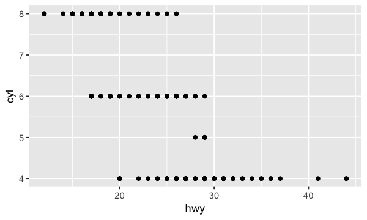

```r
ggplot(mpg, aes(x = hwy, y = cyl)) +
  geom_point()
```

### Exercise 4

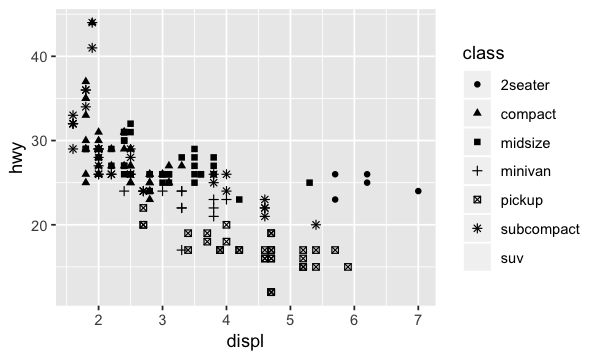

```r
ggplot(data = mpg) +
  geom_point(mapping = aes(x = displ, y = hwy, shape = class))
```

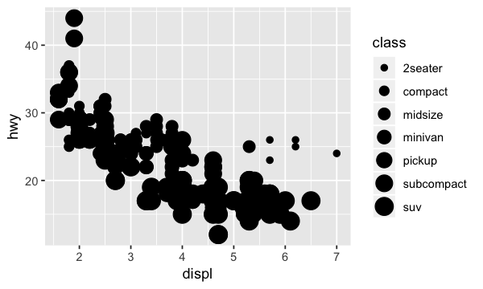

```r
ggplot(data = mpg) +
  geom_point(mapping = aes(x = displ, y = hwy, size = class))
```

### Exercise 5

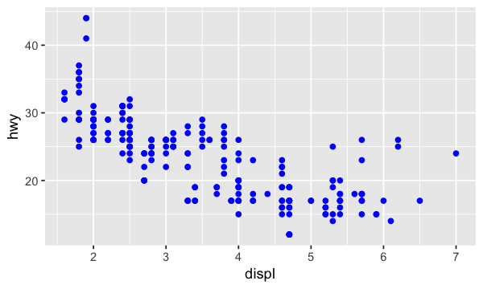

```r
ggplot(data = mpg) +
  geom_point(mapping = aes(x = displ, y = hwy), color = "blue")
```

### Exercise 6

```r
glimpse(mpg)
```

```
Observations: 234
Variables: 11
$ manufacturer <chr> "audi", "audi", "audi", "audi", "audi", "audi", "audi"...
$ model        <chr> "a4", "a4", "a4", "a4", "a4", "a4", "a4", "a4 quattro"...
$ displ        <dbl> 1.8, 1.8, 2.0, 2.0, 2.8, 2.8, 3.1, 1.8, 1.8, 2.0, 2.0,...
$ year         <int> 1999, 1999, 2008, 2008, 1999, 1999, 2008, 1999, 1999, ...
$ cyl          <int> 4, 4, 4, 4, 6, 6, 6, 4, 4, 4, 4, 6, 6, 6, 6, 6, 6, 8, ...
$ trans        <chr> "auto(l5)", "manual(m5)", "manual(m6)", "auto(av)", "a...
$ drv          <chr> "f", "f", "f", "f", "f", "f", "f", "4", "4", "4", "4",...
$ cty          <int> 18, 21, 20, 21, 16, 18, 18, 18, 16, 20, 19, 15, 17, 17...
$ hwy          <int> 29, 29, 31, 30, 26, 26, 27, 26, 25, 28, 27, 25, 25, 25...
$ fl           <chr> "p", "p", "p", "p", "p", "p", "p", "p", "p", "p", "p",...
$ class        <chr> "compact", "compact", "compact", "compact", "compact",...
```

Alternatively, if you are using RStudio then by just type `mpg` the tibble should give you the variable type information.

### Exercise 7

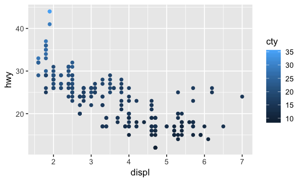

```r
ggplot(mpg, aes(x = displ, y = hwy, color = cty)) +
  geom_point()
```

Instead of using discrete colors, the continuous variable uses a scale that varies from a light to dark blue color

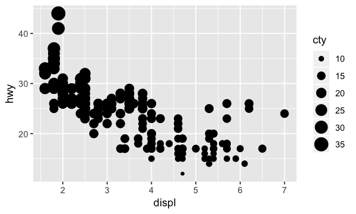

```r
ggplot(mpg, aes(x = displ, y = hwy, size = cty)) +
  geom_point()
```

```r
#ggplot(mpg, aes(x = displ, y = hwy, shape = cty)) +
#  geom_point()
# ERROR while rich displaying an object: Error: A continuous variable can not be mapped to shape
```

### Exercise 8

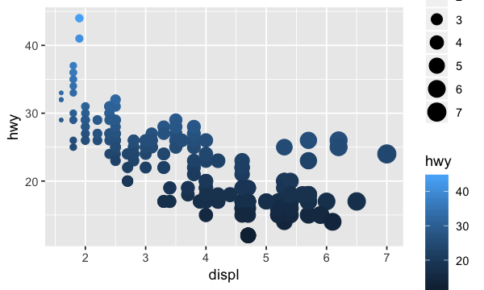

```r
ggplot(mpg, aes(x = displ, y = hwy, colour = hwy, size = displ)) +
  geom_point()
```

Not best practice! Unless it's really needed.

### Exercise 9

Stroke changes the size of the border for shapes (21-25). These are filled shapes in which the color and size of the border can differ from that of the filled interior of the shape.

For example:

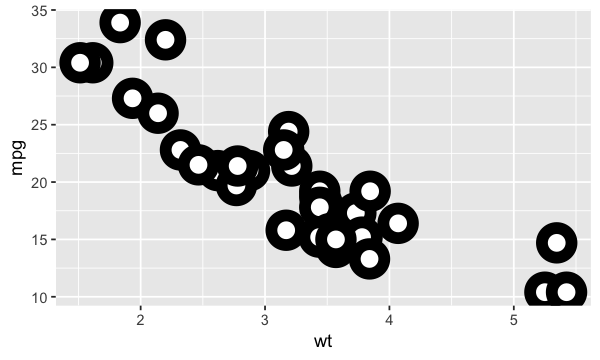

```r
ggplot(mtcars, aes(wt, mpg)) +
  geom_point(shape = 21, colour = "black", fill = "white", size = 5, stroke = 5)
```

### Exercise 10

Aesthetics can also be mapped to expressions (code like displ < 5). It will create a temporary variable which takes values from the result of the expression. In this case, it is logical variable which is `TRUE` or `FALSE`.

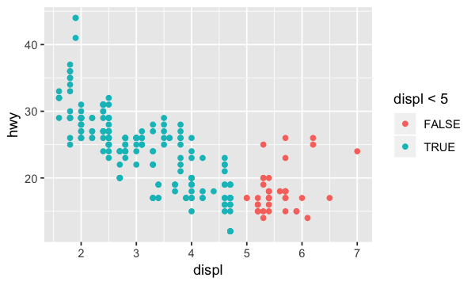

```r
ggplot(mpg, aes(x = displ, y = hwy, colour = displ < 5)) +
  geom_point()
```

### Exercise 11

The arguments `nrow` (`ncol`) determines the number of rows (columns) to use when laying out the facets. It is necessary since `facet_wrap()` only facets on one variable. These arguments are unnecessary for `facet_grid()` since the number of rows and columns are determined by the number of unique values of the variables specified.

### Exercise 12

If `FALSE`, the default, missing values are removed with a warning. If `TRUE`, missing values are silently removed.

### Exercise 13

Show legend hides the legend box. In this code, without show legend, there is a legend.

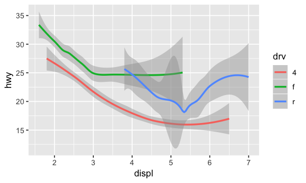

```r
ggplot(data = mpg) +
  geom_smooth(
    mapping = aes(x = displ, y = hwy, colour = drv),
  )
```

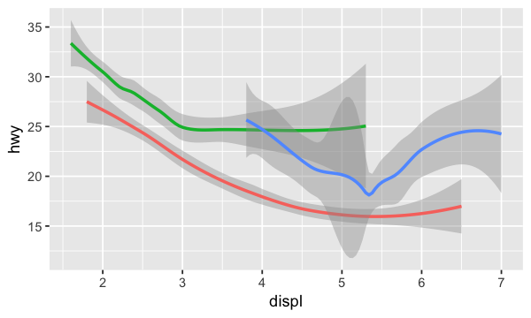

```r
ggplot(data = mpg) +
  geom_smooth(
    mapping = aes(x = displ, y = hwy, colour = drv),
    show.legend = FALSE
  )
```

### Exercise 14

No. Because both geom_point() and geom_smooth() use the same data and mappings. They will inherit those options from the ggplot() object, and thus don’t need to specified again.

### Exercise 15

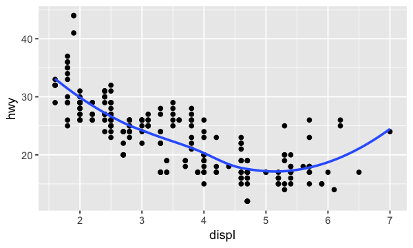

```r
ggplot(mpg, aes(x = displ, y = hwy)) +
  geom_point() +
  geom_smooth(se = FALSE)
```

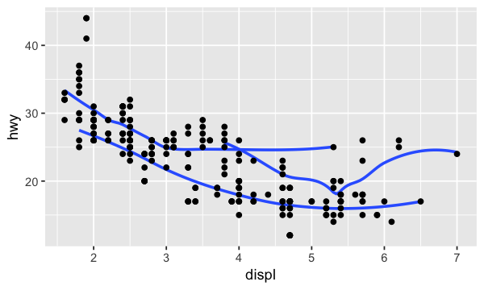

```r
ggplot(mpg, aes(x = displ, y = hwy)) +
  geom_smooth(mapping = aes(group = drv), se = FALSE) +
  geom_point()
```

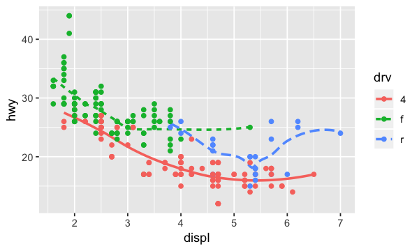

```r
ggplot(data = mpg, mapping = aes(x = displ, y = hwy, color = drv)) +
  geom_smooth(mapping = aes(linetype = drv), se = FALSE) +
  geom_point()
```

### Exercise 16

The default geom for `stat_summary()` is `geom_pointrange()` (see the `stat`) argument.

But, the default stat for `geom_pointrange()` is `identity()`, so use `geom_pointrange(stat = "summary")`.

```
No summary function supplied, defaulting to `mean_se()
```

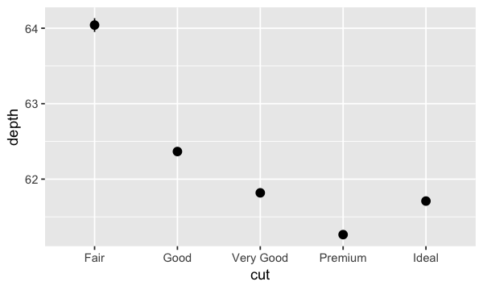

```r
ggplot(data = diamonds) +
  geom_pointrange(
    mapping = aes(x = cut, y = depth),
    stat = "summary",
  )
```

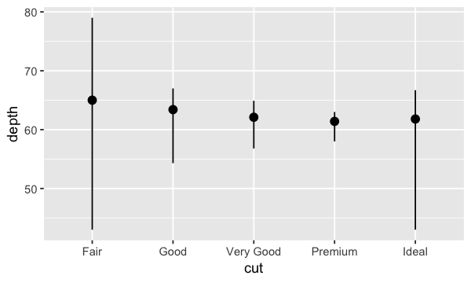

```r
ggplot(data = diamonds) +
  geom_pointrange(
    mapping = aes(x = cut, y = depth),
    stat = "summary",
    fun.ymin = min,
    fun.ymax = max,
    fun.y = median
  )
```

### Exercise 17

The function `stat_smooth()` calculates the following statistics:

- `y`: predicted value
- `ymin`: lower value of the confidence interval
- `ymax`: upper value of the confidence interval
- `se`: standard error

> ```
> stat_smooth(mapping = NULL, data = NULL, geom = "smooth",
>   position = "identity", ..., method = "auto", formula = y ~ x,
>   se = TRUE, n = 80, span = 0.75, fullrange = FALSE, level = 0.95,
>   method.args = list(), na.rm = FALSE, show.legend = NA,
>   inherit.aes = TRUE)
> ```

### Exercise 18

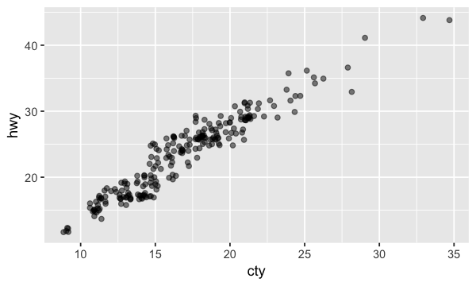

```r
ggplot(data = mpg, mapping = aes(x = cty, y = hwy)) +
  geom_point(position = "jitter", alpha = 1/2)
```

### Exercise 19

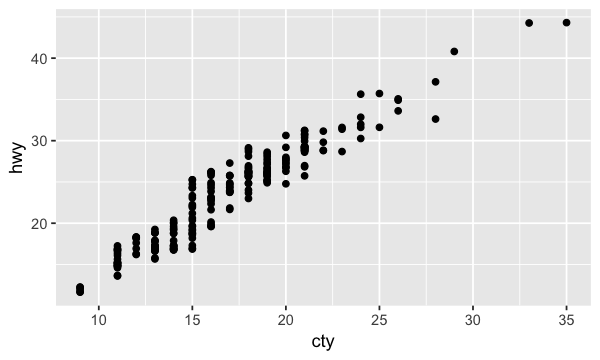

```r
ggplot(data = mpg, mapping = aes(x = cty, y = hwy)) +
  geom_point(position = position_jitter(width = 0))
```

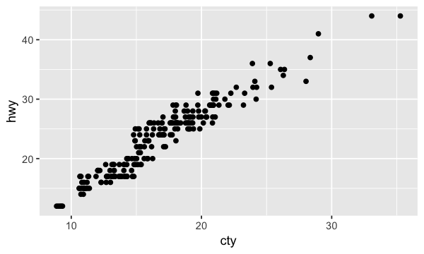

```r
ggplot(data = mpg, mapping = aes(x = cty, y = hwy)) +
  geom_point(position = position_jitter(height = 0))
```

### Exercise 20

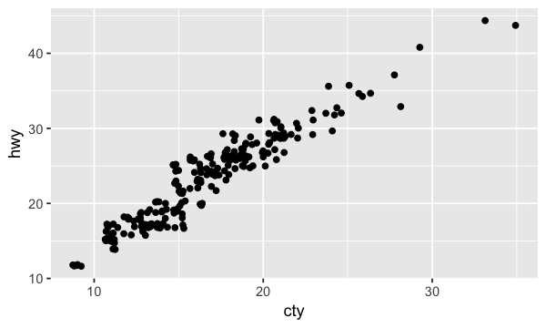

```r
ggplot(data = mpg, mapping = aes(x = cty, y = hwy)) +
  geom_jitter()
```

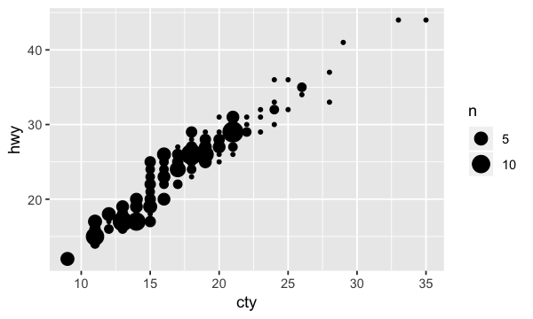

```r
ggplot(data = mpg, mapping = aes(x = cty, y = hwy)) +
  geom_count()
```

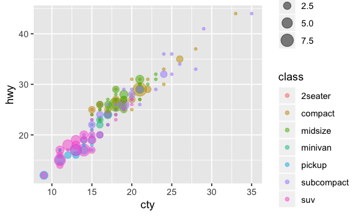

```r
ggplot(data = mpg, mapping = aes(x = cty, y = hwy, color = class)) +
  geom_count(alpha = 1/2)
```

### Exercise 21

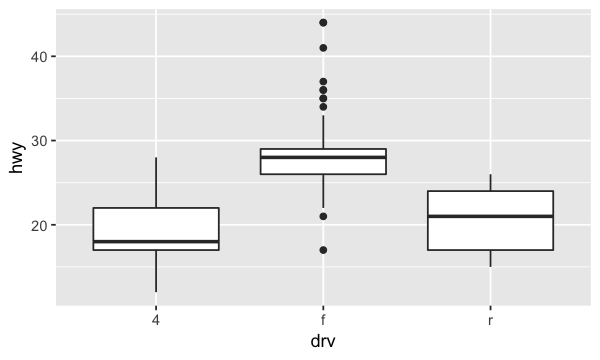

```r
ggplot(data = mpg, aes(x = drv, y = hwy)) +
  geom_boxplot()
```

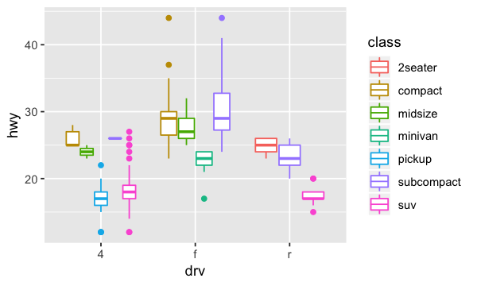

```r
ggplot(data = mpg, aes(x = drv, y = hwy, colour = class)) +
  geom_boxplot()
```

### Exercise 22

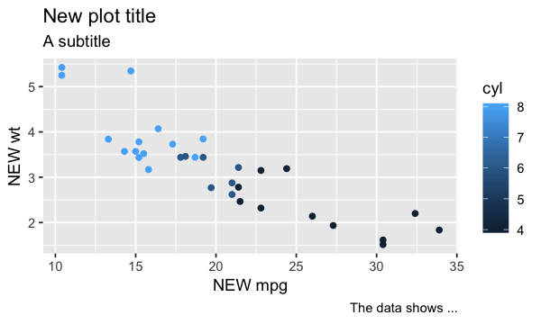

```r
p <- ggplot(mtcars, aes(mpg, wt, colour = cyl)) + geom_point()

# The plot title appears at the top-left, with the subtitle
# display in smaller text underneath it
p + labs(title = "New plot title", subtitle = "A subtitle", x = "NEW mpg", y = "NEW wt", caption = "The data shows ...")
```

### Exercise 23

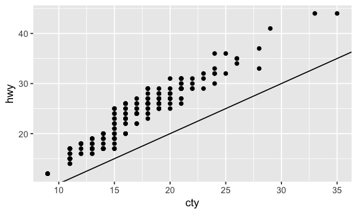

```r
ggplot(data = mpg, mapping = aes(x = cty, y = hwy)) +
  geom_point() +
  geom_abline()
```